# ANOVA Medidas Repetidas

Esteban Arroyo

02-12-2025-12-02

El ANOVA de medidas repetidas se utiliza para analizar datos donde se mide a los mismos sujetos más de una vez. Esta prueba también se conoce como ANOVA intrasujetos o ANOVA con medidas repetidas. El término “intrasujetos” significa que se mide a los mismos individuos en la misma variable de resultado en diferentes momentos o condiciones.

Para este ejemplo se usaran los datos y propuesta analítica de este link: https://www.datanovia.com/en/lessons/repeated-measures-anova-in-r/

Estos datos corresponden a la puntuación de autoestima de 10 individuos (la variable de resultado o dependiente) en tres momentos durante una dieta específica para determinar si su autoestima mejoró.

En función de esto, nos planteamos las siguientes hipótesis:

- $H_0:$ La puntuación promedio de la autoestima es la misma en los tres momentos de la dieta
- $H_1:$ Al menos una de los promedios de las puntuaciones los tres momentos de la dieta es diferente.

### Cargamos las librerías a usar

```r
library(dplyr)       # Para manipulación de datos en dataframes
library(ggpubr)      # Representación gráfica
library(rstatix)     # Analisis estadístico y Anova de medidas repetidas
library(ez)          # Otra librería para Anova de medidas repetidas
```

Cargamos los datos

| id | tiempo | puntuacion |
| --- | --- | --- |
| 1 | tiempo_1 | 61 |
| 2 | tiempo_1 | 64 |
| 3 | tiempo_1 | 62 |
| 4 | tiempo_1 | 60 |
| 5 | tiempo_1 | 65 |
| 6 | tiempo_1 | 64 |
| 7 | tiempo_1 | 63 |
| 8 | tiempo_1 | 65 |
| 9 | tiempo_1 | 60 |
| 10 | tiempo_1 | 61 |
| 1 | tiempo_2 | 81 |
| 2 | tiempo_2 | 79 |
| 3 | tiempo_2 | 84 |
| 4 | tiempo_2 | 77 |
| 5 | tiempo_2 | 83 |
| 6 | tiempo_2 | 80 |
| 7 | tiempo_2 | 79 |
| 8 | tiempo_2 | 76 |
| 9 | tiempo_2 | 75 |
| 10 | tiempo_2 | 77 |
| 1 | tiempo_3 | 64 |
| 2 | tiempo_3 | 65 |
| 3 | tiempo_3 | 66 |
| 4 | tiempo_3 | 67 |
| 5 | tiempo_3 | 65 |
| 6 | tiempo_3 | 62 |
| 7 | tiempo_3 | 67 |
| 8 | tiempo_3 | 68 |
| 9 | tiempo_3 | 62 |
| 10 | tiempo_3 | 64 |

Factorizamos la variable de momentos o condiciones, en este caso se llama “tiempo”

```r
base$tiempo <- factor(base$tiempo)   #Esto le indica al sistema que es una variable categórica
```

Hacemos un analisis descriptivo

```r
base %>% group_by(tiempo) %>% get_summary_stats(puntuacion, type="mean_sd")
```

```
# A tibble: 3 × 5
  tiempo   variable       n  mean    sd
  <fct>    <fct>      <dbl> <dbl> <dbl>
1 tiempo_1 puntuacion    10  62.5  1.96
2 tiempo_2 puntuacion    10  79.1  2.96
3 tiempo_3 puntuacion    10  65    2.06
```

Realizamos una visualización

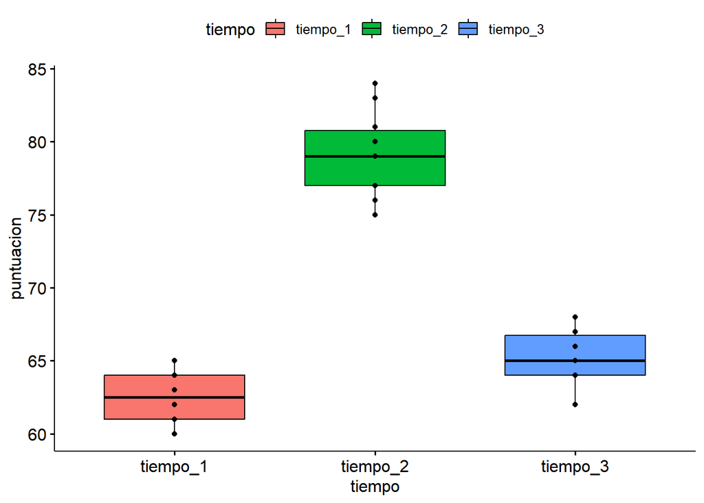

```r
ggboxplot(base, x = "tiempo", y = "puntuacion", add = "point", fill="tiempo")
```

Verificamos los supuestos:

1.- Presencia de Outliers

```r
base %>%
  group_by(tiempo) %>%
  identify_outliers(puntuacion)
```

```
[1] tiempo     id         puntuacion is.outlier is.extreme
<0 rows> (o 0- extensión row.names)
```

No hay presencia de Outliers o de valores atípicos

2.- Normalidad

```r
base %>%
  group_by(tiempo) %>%
  shapiro_test(puntuacion)
```

```
# A tibble: 3 × 4
  tiempo   variable   statistic     p
  <fct>    <chr>          <dbl> <dbl>
1 tiempo_1 puntuacion     0.898 0.206
2 tiempo_2 puntuacion     0.958 0.758
3 tiempo_3 puntuacion     0.940 0.550
```

Se observa que la variable “puntuación” se distribuye de forma normal en los tres tiempos o momentos de la dieta

Tambien lo podemos visualizar con un gráfico de qq-plot

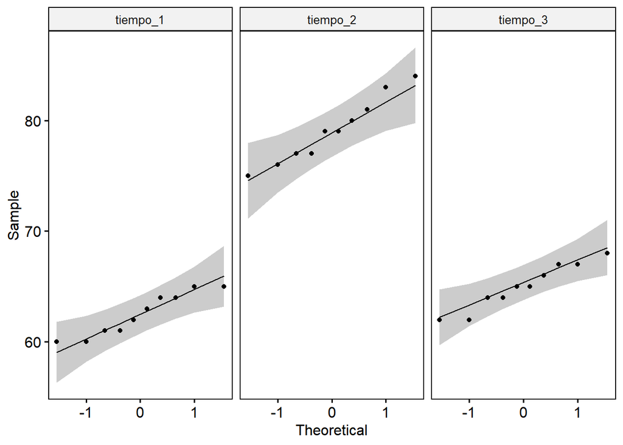

```r
ggqqplot(base, "puntuacion", facet.by = "tiempo")
```

3.- Homocedasticidad

```r
base %>% levene_test(puntuacion~tiempo)
```

```
# A tibble: 1 × 4
    df1   df2 statistic     p
  <int> <int>     <dbl> <dbl>
1     2    27     0.878 0.427
```

Se observa homocedasticidad, es decir, existe igualdad de varianzas de la puntuación entre los tres tiempos o momentos de la dieta

4.- Esfericidad

```r
res.aov <- anova_test(data = base, dv = puntuacion, wid = id, within = tiempo)
res.aov$`Mauchly's Test for Sphericity`
```

```
  Effect     W    p p<.05
1 tiempo 0.823 0.46
```

Se aprecia que el valor p = 0.46 es mayor al umbral de 0.05, lo que indica que estos datos se ajustan al supuesto de esfericidad, es decir, la varianza de las diferencia entre cada par de “tiempos” sean iguales.

### Aplicamos el Anova de medidas repetidas

```r
ezANOVA(data=base, dv=puntuacion, wid=id, within=tiempo, detailed = TRUE, return_aov = TRUE)
```

```
$ANOVA
       Effect DFn DFd        SSn      SSd          F            p p<.05
1 (Intercept)   1   9 142278.533 68.13333 18794.1311 2.971119e-16     *
2      tiempo   2  18   1602.067 83.26667   173.1617 1.754156e-12     *
        ges
1 0.9989370
2 0.9136568

$`Mauchly's Test for Sphericity`
  Effect         W         p p<.05
2 tiempo 0.8234225 0.4597175

$`Sphericity Corrections`
  Effect       GGe        p[GG] p[GG]<.05     HFe        p[HF] p[HF]<.05
2 tiempo 0.8499228 6.741868e-11         * 1.02727 1.754156e-12         *

$aov

Call:
aov(formula = formula(aov_formula), data = data)

Grand Mean: 68.86667

Stratum 1: id

Terms:
                Residuals
Sum of Squares   68.13333
Deg. of Freedom         9

Residual standard error: 2.751431

Stratum 2: id:tiempo

Terms:
                   tiempo Residuals
Sum of Squares  1602.0667   83.2667
Deg. of Freedom         2        18

Residual standard error: 2.150797
Estimated effects may be unbalanced
```

Se aprecia que el tiempo posee un valor-F de 173.1617, lo que es significativo al nivel de 0.01, es decir, la puntuación de autoestima cambia con el tiempo.

Se observa también el tamaño del efecto en el valor del Eta cuadrado (ges=0.91) (Generalized Eta-Squared), esto indica que es un efecto muy grande lo que indica que la variable independiente (tiempo) explica aproximadamente el 91% de la varianza en la variable dependiente (puntuación).

En general se acepta que un valor de Eta:

- 0.01 es un efecto bajo
- 0.06 es un efecto medio
- 0.14 es un efecto grande

El tamaño del efecto en un ANOVA de medidas repetidas es importante porque indica la magnitud y significancia práctica de los resultados. Permite cuantificar cuánto la variable independiente afecta a la dependiente y es esencial para determinar el tamaño de la muestra necesario y para comparar la fuerza de los efectos entre diferentes estudios.

### Pruebas de Comparaciones múltiples - Post-Hoc

```r
comparacion_multiple <- base %>%
  pairwise_t_test(puntuacion~tiempo, paired=TRUE, p.adjust.method = "bonferroni")

comparacion_multiple
```

```
# A tibble: 3 × 10
  .y.     group1 group2    n1    n2 statistic    df       p   p.adj p.adj.signif
* <chr>   <chr>  <chr>  <int> <int>     <dbl> <dbl>   <dbl>   <dbl> <chr>
1 puntua… tiemp… tiemp…    10    10    -17.6      9 2.85e-8 8.55e-8 ****
2 puntua… tiemp… tiemp…    10    10     -3.21     9 1.1 e-2 3.2 e-2 *
3 puntua… tiemp… tiemp…    10    10     12.5      9 5.51e-7 1.65e-6 ****
```

Al realizar las compraciones múltiples, se encontraron diferencias significativas entre todos los tiempos.

### Visualization: box plots with p-values

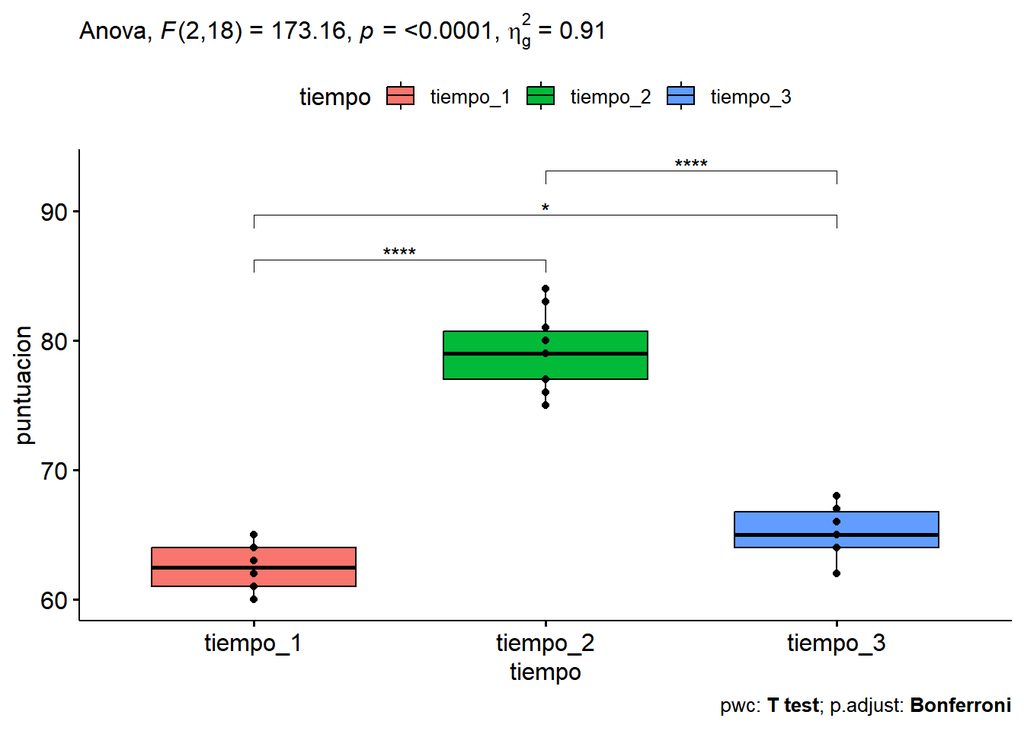

```r
comparacion_multiple <- comparacion_multiple %>% add_xy_position(x = "tiempo")

ggboxplot(base, x = "tiempo", y = "puntuacion", add = "point", fill="tiempo")+
  stat_pvalue_manual(comparacion_multiple) +
  labs(
    subtitle = get_test_label(res.aov, detailed = TRUE),
    caption = get_pwc_label(comparacion_multiple)
  )
```

## ANOVA DE MEDIDAS REPETIDAS CON DOS FACTORES

Los datos se refieren a la autoestima de 12 personas, medida en dos ensayos: control (placebo) y dieta (tratamiento). Cada participante realizó los dos ensayos y la autoestima se registró en tres momentos: al inicio (t1), a la mitad (t2) y al final (t3) de los ensayos.

La cuestión es investigar si este tratamiento dietético a corto plazo puede inducir un aumento significativo de la autoestima con el tiempo. En otras palabras, queremos saber si existe una interacción significativa entre la dieta y el tiempo en la autoestima.

En este caso, se aplcará un ANOVA de medidas repetidas de dos vías para determinar si existe una interacción significativa entre la dieta y el tiempo en la autoestima.

Cargamos y visualizamos una parte de los datos, ya que la ser 12 sujetos x 3 categorías de tiempo y 2 ensayos da un total de (12x3x2) 72 filas.

```r
head(selfesteem2, 30) %>% kbl() %>% kable_classic_2(full_width = F, position = "center")
```

| id | treatment | time | score |
| --- | --- | --- | --- |
| 1 | ctr | t1 | 83 |
| 2 | ctr | t1 | 97 |
| 3 | ctr | t1 | 93 |
| 4 | ctr | t1 | 92 |
| 5 | ctr | t1 | 77 |
| 6 | ctr | t1 | 72 |
| 7 | ctr | t1 | 92 |
| 8 | ctr | t1 | 92 |
| 9 | ctr | t1 | 95 |
| 10 | ctr | t1 | 92 |
| 11 | ctr | t1 | 92 |
| 12 | ctr | t1 | 79 |
| 1 | Diet | t1 | 84 |
| 2 | Diet | t1 | 100 |
| 3 | Diet | t1 | 91 |
| 4 | Diet | t1 | 91 |
| 5 | Diet | t1 | 74 |
| 6 | Diet | t1 | 76 |
| 7 | Diet | t1 | 90 |
| 8 | Diet | t1 | 89 |
| 9 | Diet | t1 | 93 |
| 10 | Diet | t1 | 90 |
| 11 | Diet | t1 | 93 |
| 12 | Diet | t1 | 80 |
| 1 | ctr | t2 | 77 |
| 2 | ctr | t2 | 95 |
| 3 | ctr | t2 | 92 |
| 4 | ctr | t2 | 92 |
| 5 | ctr | t2 | 73 |
| 6 | ctr | t2 | 65 |

Hacemos un analisis descriptivo

```r
selfesteem2 %>% group_by(treatment, time) %>% get_summary_stats(score, type="mean_sd")
```

```
# A tibble: 6 × 6
  treatment time  variable     n  mean    sd
  <fct>     <fct> <fct>    <dbl> <dbl> <dbl>
1 ctr       t1    score       12  88    8.08
2 ctr       t2    score       12  83.8 10.2
3 ctr       t3    score       12  78.7 10.5
4 Diet      t1    score       12  87.6  7.62
5 Diet      t2    score       12  87.8  7.42
6 Diet      t3    score       12  87.7  8.14
```

Realizamos una visualización

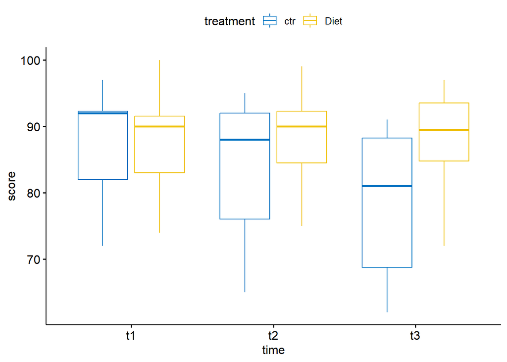

```r
ggboxplot(selfesteem2, x = "time", y = "score", color = "treatment", palette = "jco")
```

Verificamos los supuestos:

1.- Presencia de Outliers

```r
selfesteem2 %>%
  group_by(treatment, time) %>%
  identify_outliers(score)
```

```
[1] treatment  time       id         score      is.outlier is.extreme
<0 rows> (o 0- extensión row.names)
```

No hay presencia de Outliers o de valores atípicos

2.- Normalidad

```r
selfesteem2 %>%
  group_by(treatment, time) %>%
  shapiro_test(score)
```

```
# A tibble: 6 × 5
  treatment time  variable statistic      p
  <fct>     <fct> <chr>        <dbl>  <dbl>
1 ctr       t1    score        0.828 0.0200
2 ctr       t2    score        0.868 0.0618
3 ctr       t3    score        0.887 0.107
4 Diet      t1    score        0.919 0.279
5 Diet      t2    score        0.923 0.316
6 Diet      t3    score        0.886 0.104
```

La puntuación de autoestima se distribuyó normalmente en cada punto temporal (p > 0,05), excepto para el tratamiento ctr en t1, según la evaluación mediante la prueba de Shapiro-Wilk.

Tambien lo podemos visualizar con un gráfico de qq-plot

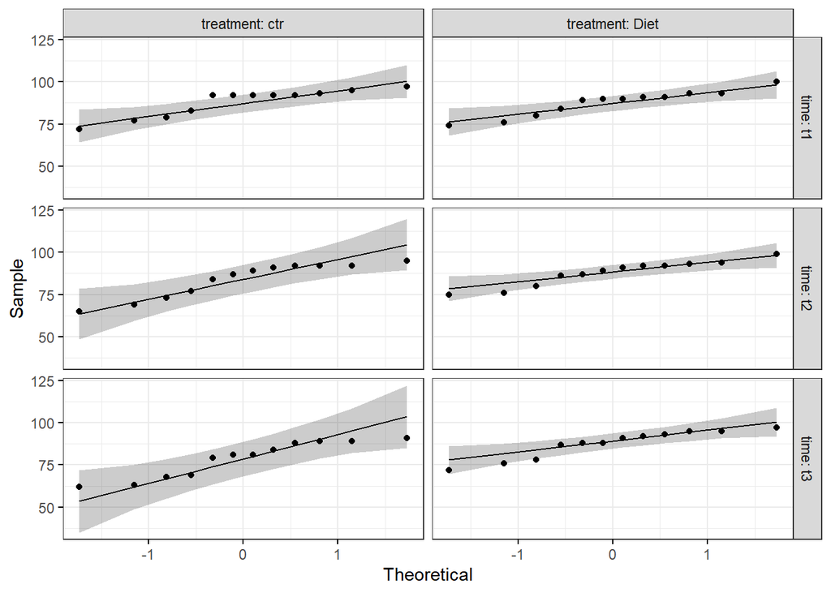

```r
ggqqplot(selfesteem2, "score", ggtheme = theme_bw()) + facet_grid(time ~ treatment, labeller = "label_both")
```

Se puede apreciar que, como todos los puntos caen aproximadamente a lo largo de la línea de referencia, podemos asumir normalidad.

3.- Homocedasticidad

```r
selfesteem2$interaccion <- interaction(selfesteem2$treatment, selfesteem2$time) # Combinar los factores

selfesteem2 %>% levene_test(score~interaccion)
```

```
# A tibble: 1 × 4
    df1   df2 statistic     p
  <int> <int>     <dbl> <dbl>
1     5    66     0.536 0.749
```

Se observa homocedasticidad, es decir, existe igualdad de varianzas de la puntuación o “score” entre los tres tiempos combinados con los dos tratamientos.

4.- Esfericidad

```r
res.aov <- anova_test(
  data = selfesteem2, dv = score, wid = id,
  within = c(treatment, time))
res.aov$`Mauchly's Test for Sphericity`
```

```
          Effect     W     p p<.05
1           time 0.469 0.023     *
2 treatment:time 0.616 0.089
```

Se aprecia que el “tiempo” tiene un p.valor (0.023) menor que el umbral de 0.05, lo que indica que el tiempo no se ajusta al supuesto de esfericidad, es decir, se rechaza el supuesto que la varianza de las diferencia entre cada par de “tiempos” sean iguales, sin embargo su interacción con los “tratamientos” si se ajusta al supuesto.

Para estos casos, usamos la corrección de Esfericidad de Mauchly

```r
res.aov$`Sphericity Corrections`
```

```
##           Effect   GGe      DF[GG]    p[GG] p[GG]<.05   HFe      DF[HF]
## 1           time 0.653 1.31, 14.37 5.03e-05         * 0.705 1.41, 15.52
## 2 treatment:time 0.723  1.45, 15.9 1.25e-05         * 0.803 1.61, 17.66
##      p[HF] p[HF]<.05
## 1 2.81e-05         *
## 2 4.82e-06         *
```

…y ahora vemos, que considerando la corrección, si se ajusta al supuesto de esfericidad.

### Aplicamos el Anova de medidas repetidas

```r
ezANOVA(data=selfesteem2, dv=score, wid=id, within=c(treatment,time), detailed = TRUE, return_aov = TRUE)
```

```
$ANOVA
          Effect DFn DFd         SSn        SSd          F            p p<.05
1    (Intercept)   1  11 527535.6806 4641.15278 1250.31275 1.112064e-12     *
2      treatment   1  11    316.6806  224.15278   15.54068 2.303450e-03     *
3           time   2  22    258.6944  103.97222   27.36922 1.075243e-06     *
4 treatment:time   2  22    266.3611   96.30556   30.42371 4.629997e-07     *
         ges
1 0.99048898
2 0.05883780
3 0.04858771
4 0.04995572

$`Mauchly's Test for Sphericity`
          Effect         W          p p<.05
3           time 0.4690776 0.02271033     *
4 treatment:time 0.6160746 0.08874965

$`Sphericity Corrections`
          Effect       GGe        p[GG] p[GG]<.05       HFe        p[HF]
3           time 0.6532010 5.033982e-05         * 0.7054565 2.810626e-05
4 treatment:time 0.7225823 1.254728e-05         * 0.8028383 4.815620e-06
  p[HF]<.05
3         *
4         *

$aov

Call:
aov(formula = formula(aov_formula), data = data)

Grand Mean: 85.59722

Stratum 1: id

Terms:
                Residuals
Sum of Squares   4641.153
Deg. of Freedom        11

Residual standard error: 20.54076
```

[output cut: 17 more lines]

```
Deg. of Freedom        2        22

Residual standard error: 2.173939
2 out of 4 effects not estimable
Estimated effects may be unbalanced

Stratum 4: id:treatment:time

Terms:
                treatment:time Residuals
Sum of Squares       266.36111  96.30556
Deg. of Freedom              2        22

Residual standard error: 2.092254
Estimated effects may be unbalanced
```

Existe una interacción bidireccional estadísticamente significativa entre el tratamiento y el tiempo, F(2, 22) = 30,4, p < 0,0001.

### Pruebas de Comparaciones múltiples - Post-Hoc

Para este punto podemos hacer dos tipos de test:

- Efecto principal simple: ejecutar un modelo unidireccional de la primera variable (factor A) en cada nivel de la segunda variable (factor B).
- Comparaciones por pares simples: si el efecto principal simple es significativo, realizar múltiples comparaciones por pares para determinar qué grupos son diferentes.

**Efecto del tratamiento**

En este caso, analizaremos el efecto del tratamiento en la autoestima en cada momento.

```r
# Efecto del tratamiento en cada punto temporal
selfesteem2 %>%
  group_by(time) %>%
  anova_test(dv = score, wid = id, within = treatment) %>%
  get_anova_table() %>%
  adjust_pvalue(method = "bonferroni")
```

```
# A tibble: 3 × 9
  time  Effect      DFn   DFd      F       p `p<.05`      ges   p.adj
  <fct> <chr>     <dbl> <dbl>  <dbl>   <dbl> <chr>      <dbl>   <dbl>
1 t1    treatment     1    11  0.376 0.552   ""      0.000767 1
2 t2    treatment     1    11  9.03  0.012   "*"     0.052    0.036
3 t3    treatment     1    11 30.9   0.00017 "*"     0.199    0.00051
```

```r
# Comparaciones por pares entre grupos de tratamiento
selfesteem2 %>%
  group_by(time) %>%
  pairwise_t_test(
    score ~ treatment, paired = TRUE,
    p.adjust.method = "bonferroni"
  )
```

```
# A tibble: 3 × 11
  time  .y.   group1 group2    n1    n2 statistic    df       p   p.adj
* <fct> <chr> <chr>  <chr>  <int> <int>     <dbl> <dbl>   <dbl>   <dbl>
1 t1    score ctr    Diet      12    12     0.613    11 0.552   0.552
2 t2    score ctr    Diet      12    12    -3.00     11 0.012   0.012
3 t3    score ctr    Diet      12    12    -5.56     11 0.00017 0.00017
# ℹ 1 more variable: p.adj.signif <chr>
```

Considerando el valor p ajustado por Bonferroni (p.adj), se observa que el efecto principal simple del tratamiento no fue significativo en el momento t1 (p = 1). Se vuelve significativo en t2 (p = 0,036) y t3 (p = 0,00051).

**Efecto del tiempo**

Se observa que también es posible realizar el mismo análisis para la variable tiempo en cada nivel de tratamiento. No es necesario realizar este análisis.

```r
# Efecto del tiempo en cada nivel de tratamiento
selfesteem2 %>%
  group_by(treatment) %>%
  anova_test(dv = score, wid = id, within = time) %>%
  get_anova_table() %>%
  adjust_pvalue(method = "bonferroni")

# Comparaciones por pares entre puntos de tiempo
selfesteem2 %>%
  group_by(treatment) %>%
  pairwise_t_test(
    score ~ time, paired = TRUE,
    p.adjust.method = "bonferroni"
  )
```

[output not shown]

**Comparaciones para la variable de tratamiento**

```r
selfesteem2 %>%
  pairwise_t_test(
    score ~ treatment, paired = TRUE,
    p.adjust.method = "bonferroni"
  )
```

```
# A tibble: 1 × 10
  .y.   group1 group2    n1    n2 statistic    df        p    p.adj p.adj.signif
* <chr> <chr>  <chr>  <int> <int>     <dbl> <dbl>    <dbl>    <dbl> <chr>
1 score ctr    Diet      36    36     -4.35    35 0.000113 0.000113 ***
```

**Comparaciones para la variable tiempo**

```r
selfesteem2 %>%
  pairwise_t_test(
    score ~ time, paired = TRUE,
    p.adjust.method = "bonferroni"
  )
```

```
# A tibble: 3 × 10
  .y.   group1 group2    n1    n2 statistic    df     p p.adj p.adj.signif
* <chr> <chr>  <chr>  <int> <int>     <dbl> <dbl> <dbl> <dbl> <chr>
1 score t1     t2        24    24      2.86    23 0.009 0.027 *
2 score t1     t3        24    24      3.70    23 0.001 0.004 **
3 score t2     t3        24    24      3.75    23 0.001 0.003 **
```

Se aprecia que todas las comparaciones por pares son significativas.

### Visualization: box plots with p-values

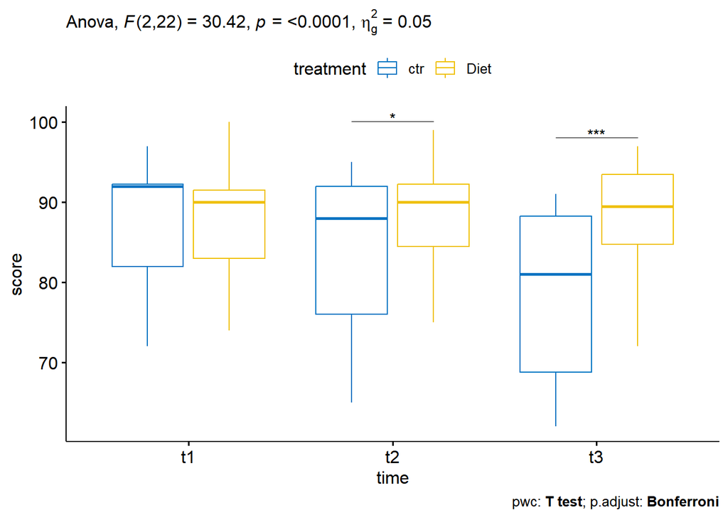

```r
pwc <- selfesteem2 %>%
  group_by(time) %>%
  pairwise_t_test(
    score ~ treatment, paired = TRUE,
    p.adjust.method = "bonferroni"
  ) %>% add_xy_position(x = "time")

ggboxplot(
  selfesteem2, x = "time", y = "score",
  color = "treatment", palette = "jco"
) +
  stat_pvalue_manual(pwc, tip.length = 0, hide.ns = TRUE) +
  labs(
    subtitle = get_test_label(res.aov, detailed = TRUE),
    caption = get_pwc_label(pwc)
  )
```